# Predictive Model for Movie Revenue Estimation and Decision Support

2023-11-22

```r
knitr::opts_chunk$set(echo = TRUE)
```

Detailed Problem Statement: The movie industry is a dynamic and complex environment where various factors influence a movie’s success, particularly its revenue. This project focuses on developing a robust “Predictive Model for Movie Revenue Estimation and Decision Support.” In an era of high uncertainty and financial risk in the film production business, understanding the determinants of movie revenue is paramount for informed decision-making, investment strategies, and marketing planning.

Movies are a unique combination of artistic expression and commercial ventures. To that end, this research investigates a multitude of features that contribute to the financial performance of a movie. These include aspects like genres, original languages, overview, popularity, production companies, release date, budget, runtime, status, tagline, vote average, vote count, credits, keywords, poster path, backdrop path, and recommendations. Each of these factors is scrutinized meticulously to unravel their individual and collective influence on movie revenue.

By conducting a comprehensive analysis of these features, this research aims to build a regression model (Linear, Decision Tree, Support Vector Machine) based on valuable insights through identifying patterns, relationships, and correlations. The findings of this study are expected to have substantial implications for movie production companies, investors, and stakeholders. They can leverage the predictive model developed in this project to make informed decisions regarding their movie investments, marketing strategies, and financial planning, ultimately contributing to the success and profitability of their ventures in the film industry.

**Importing the Movies Data**

```r
movie = read.csv("movies.csv")
head(movie)
```

```
##       id                             title                           genres
## 1 615656                 Meg 2: The Trench    Action-Science Fiction-Horror
## 2 758323               The Pope's Exorcist          Horror-Mystery-Thriller
## 3 667538  Transformers: Rise of the Beasts Action-Adventure-Science Fiction
## 4 640146 Ant-Man and the Wasp: Quantumania Action-Adventure-Science Fiction
## 5 677179                         Creed III                     Drama-Action
## 6 385687                            Fast X            Action-Crime-Thriller
##   original_language
## 1                en
## 2                en
## 3                en
## 4                en
## 5                en
## 6                en
##                                                                                                                                                                                                                                                                                                          …
```

[output cut: 69 more lines]

**Removing Unwanted Columns**

```r
library(dplyr)
remove_col <- c(1,5,7,13,16,17,18,19,20)
movie <- movie[, -remove_col]
head(movie)
```

```
##                               title                           genres
## 1                 Meg 2: The Trench    Action-Science Fiction-Horror
## 2               The Pope's Exorcist          Horror-Mystery-Thriller
## 3  Transformers: Rise of the Beasts Action-Adventure-Science Fiction
## 4 Ant-Man and the Wasp: Quantumania Action-Adventure-Science Fiction
## 5                         Creed III                     Drama-Action
## 6                            Fast X            Action-Crime-Thriller
##   original_language popularity release_date   budget   revenue runtime   status
## 1                en   8763.998   2023-08-02 1.29e+08 352056482     116 Released
## 2                en   5953.227   2023-04-05 1.80e+07  65675816     103 Released
## 3                en   5409.104   2023-06-06 2.00e+08 407045464     127 Released
## 4                en   4425.387   2023-02-15 2.00e+08 475766228     125 Released
## 5                en   3994.342   2023-03-01 7.50e+07 269000000     116 Released
## 6                en   3583.861   2023-05-17 3.40e+08 704709660     142 Released
##   vote_average vote_count
## 1        7.079       1365
## 2        7.433        545
## 3        7.340       1007
## 4        6.507       2811
## 5        7.262       1129
## 6        7.275       3694
```

**Summary of the data**

```r
summary(movie)
```

```
##     title              genres          original_language    popularity
##  Length:722649      Length:722649      Length:722649      Min.   :   0.600
##  Class :character   Class :character   Class :character   1st Qu.:   0.600
##  Mode  :character   Mode  :character   Mode  :character   Median :   0.600
##                                                           Mean   :   1.829
##                                                           3rd Qu.:   1.295
##                                                           Max.   :8763.998
##
##  release_date           budget             revenue              runtime
##  Length:722649      Min.   :0.000e+00   Min.   :       -12   Min.   :       0
##  Class :character   1st Qu.:0.000e+00   1st Qu.:         0   1st Qu.:       5
##  Mode  :character   Median :0.000e+00   Median :         0   Median :      50
##                     Mean   :3.969e+05   Mean   :    987160   Mean   :     199
##                     3rd Qu.:0.000e+00   3rd Qu.:         0   3rd Qu.:      90
##                     Max.   :5.000e+09   Max.   :2920357254   Max.   :50505050
##                                                              NA's   :34419
##     status           vote_average      vote_count
##  Length:722649      Min.   : 0.000   Min.   :    0.00
##  Class :character   1st Qu.: 0.000   1st Qu.:    0.00
##  Mode  :character   Median : 0.000   Median :    0.00
##                     Mean   : 2.444   Mean   :   27.78
##                     3rd Qu.: 5.600   3rd Qu.:    2.00
##                     Max.   :10.000   Max.   :33262.00
##
```

**Checking for missing values in the data**

```r
missing_values <- is.na(movie)
summary(missing_values)
```

```
##    title           genres        original_language popularity
##  Mode :logical   Mode :logical   Mode :logical     Mode :logical
##  FALSE:722649    FALSE:722649    FALSE:722649      FALSE:722649
##
##  release_date      budget         revenue         runtime
##  Mode :logical   Mode :logical   Mode :logical   Mode :logical
##  FALSE:722649    FALSE:722649    FALSE:722649    FALSE:688230
##                                                  TRUE :34419
##    status        vote_average    vote_count
##  Mode :logical   Mode :logical   Mode :logical
##  FALSE:722649    FALSE:722649    FALSE:722649
##
```

```r
movie_cleaned <- na.omit(movie)

write.csv(movie_cleaned, "movie_final.csv", row.names = FALSE)
```

**Importing Movie_Final data**

```r
movie_final = read.csv("movie_final.csv")
```

```r
# Format the 'budget' and 'revenue' columns to not display in scientific notation
movie_final$budget <- format(movie_final$budget, scientific = FALSE)
movie_final$revenue <- format(movie_final$revenue, scientific = FALSE)
head(movie_final)
```

```
##                               title                           genres
## 1                 Meg 2: The Trench    Action-Science Fiction-Horror
## 2               The Pope's Exorcist          Horror-Mystery-Thriller
## 3  Transformers: Rise of the Beasts Action-Adventure-Science Fiction
## 4 Ant-Man and the Wasp: Quantumania Action-Adventure-Science Fiction
## 5                         Creed III                     Drama-Action
## 6                            Fast X            Action-Crime-Thriller
##   original_language popularity release_date     budget    revenue runtime
## 1                en   8763.998   2023-08-02  129000000  352056482     116
## 2                en   5953.227   2023-04-05   18000000   65675816     103
## 3                en   5409.104   2023-06-06  200000000  407045464     127
## 4                en   4425.387   2023-02-15  200000000  475766228     125
## 5                en   3994.342   2023-03-01   75000000  269000000     116
## 6                en   3583.861   2023-05-17  340000000  704709660     142
##     status vote_average vote_count
## 1 Released        7.079       1365
## 2 Released        7.433        545
## 3 Released        7.340       1007
## 4 Released        6.507       2811
## 5 Released        7.262       1129
## 6 Released        7.275       3694
```

```r
tail(movie_final)
```

```
##                            title      genres original_language popularity
## 688225         Historic Maryland Documentary                en        0.6
## 688226         The Fistic Mystic   Animation                en        0.6
## 688227               The Killers                            ru        0.6
## 688228            Island of Love       Drama                id        0.6
## 688229 Shania Twain - by Stetson       Music                en        0.6
## 688230             Gising Sining                            tl        0.6
##        release_date     budget    revenue runtime   status vote_average
## 688225   1941-12-27          0          0       9 Released            0
## 688226   1946-11-28          0          0       6 Released            7
## 688227   1971-01-01          0          0      20 Released            0
## 688228   1978-01-01          0          0     107 Released            0
## 688229   2005-02-18          0          0       0 Released            0
## 688230                       0          0      19 Released            0
##        vote_count
## 688225          0
## 688226          2
## 688227          0
## 688228          0
## 688229          0
## 688230          0
```

```r
# Check for missing values
missing_values <- is.na(movie_final)
summary(movie_final)
```

```
##     title              genres          original_language    popularity
##  Length:688230      Length:688230      Length:688230      Min.   :   0.600
##  Class :character   Class :character   Class :character   1st Qu.:   0.600
##  Mode  :character   Mode  :character   Mode  :character   Median :   0.600
##                                                           Mean   :   1.886
##                                                           3rd Qu.:   1.341
##                                                           Max.   :8763.998
##  release_date          budget            revenue             runtime
##  Length:688230      Length:688230      Length:688230      Min.   :       0
##  Class :character   Class :character   Class :character   1st Qu.:       5
##  Mode  :character   Mode  :character   Mode  :character   Median :      50
##                                                           Mean   :     199
##                                                           3rd Qu.:      90
##                                                           Max.   :50505050
##     status           vote_average     vote_count
##  Length:688230      Min.   : 0.00   Min.   :    0.00
##  Class :character   1st Qu.: 0.00   1st Qu.:    0.00
##  Mode  :character   Median : 0.00   Median :    0.00
##                     Mean   : 2.52   Mean   :   29.16
##                     3rd Qu.: 5.70   3rd Qu.:    2.00
##                     Max.   :10.00   Max.   :33262.00
```

```r
movie_final$budget <- as.numeric(movie_final$budget)
movie_final$revenue <- as.numeric(movie_final$revenue)
```

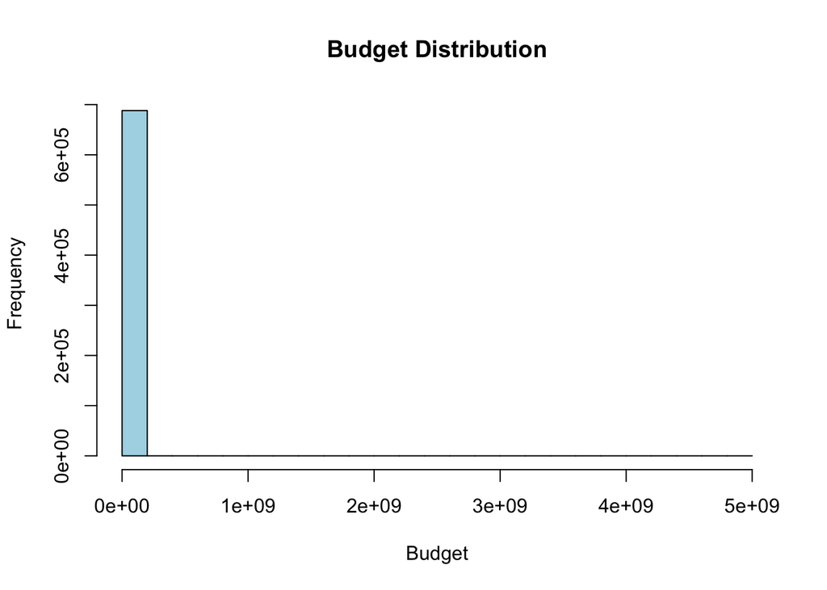

```r
# Visualize the distribution of numerical variables
#par(mfrow=c(2,2))
hist(movie_final$budget, main="Budget Distribution", xlab="Budget", col="lightblue")
```

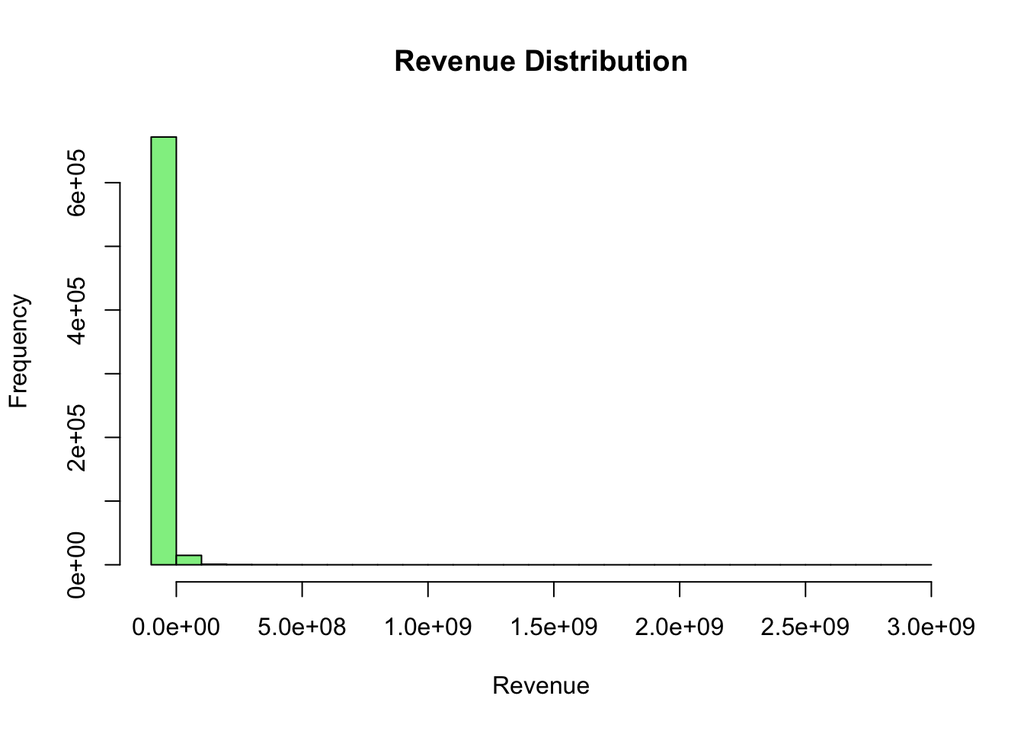

```r
hist(movie_final$revenue, main="Revenue Distribution", xlab="Revenue", col="lightgreen")
```

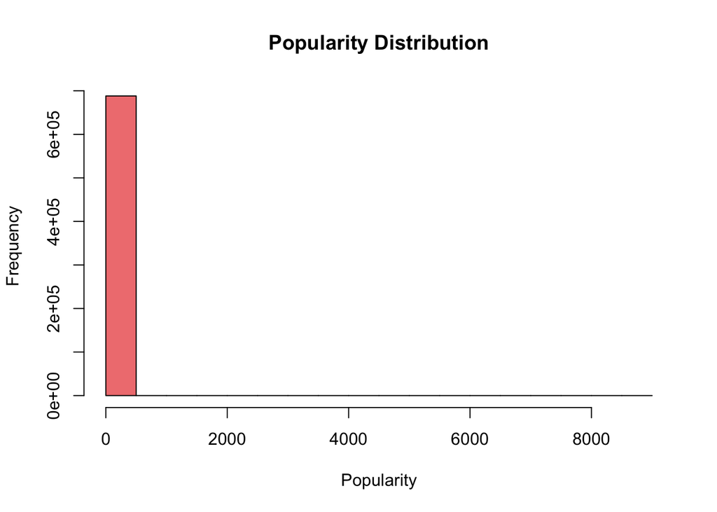

```r
hist(movie_final$popularity, main="Popularity Distribution", xlab="Popularity", col="lightcoral")
```

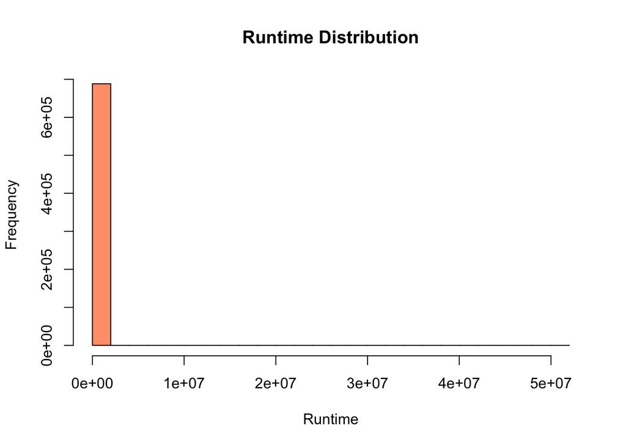

```r
hist(movie_final$runtime, main="Runtime Distribution", xlab="Runtime", col="lightsalmon")
```

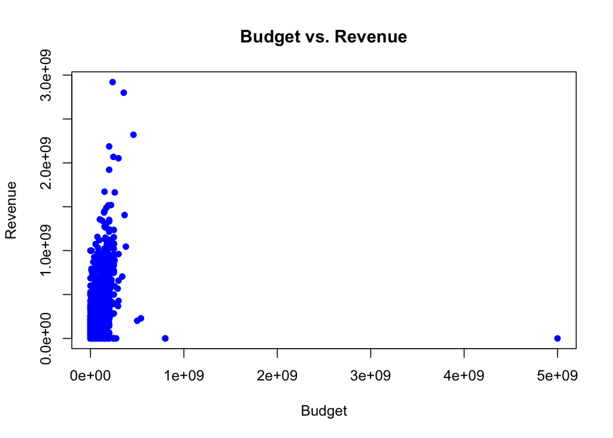

```r
# Explore relationships between variables (scatter plots)
plot(movie_final$budget, movie_final$revenue, main="Budget vs. Revenue", xlab="Budget", ylab="Revenue", col="blue", pch=16)
```

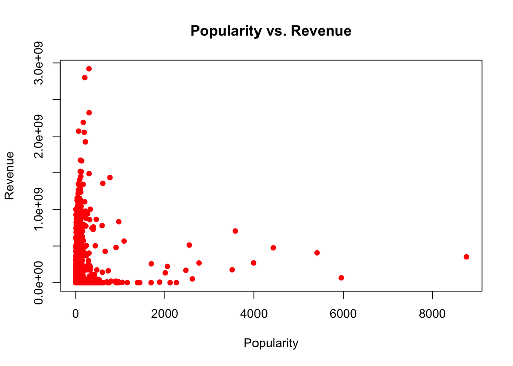

```r
plot(movie_final$popularity, movie_final$revenue, main="Popularity vs. Revenue", xlab="Popularity", ylab="Revenue", col="red", pch=16)
```

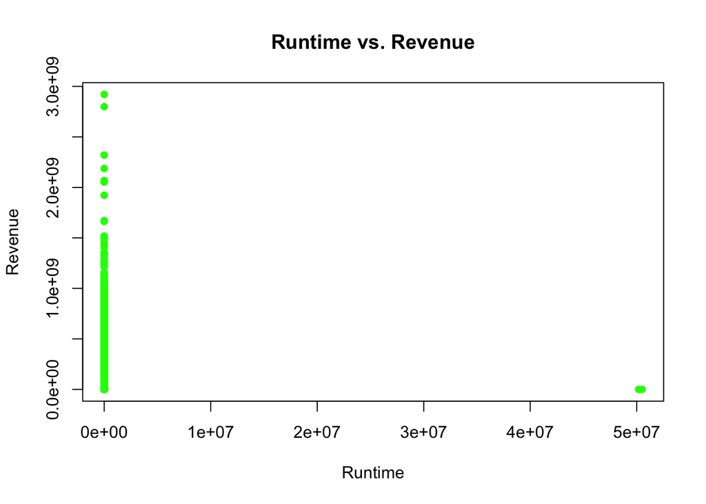

```r
plot(movie_final$runtime, movie_final$revenue, main="Runtime vs. Revenue", xlab="Runtime", ylab="Revenue", col="green", pch=16)
```

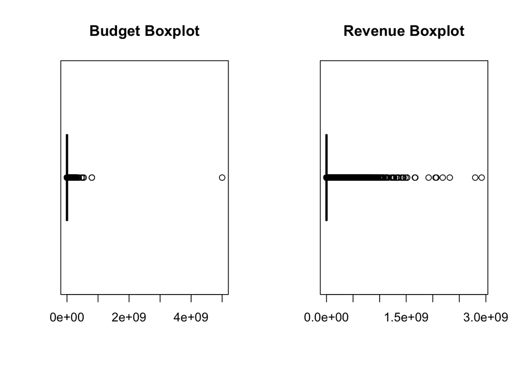

```r
# Boxplot for budget and revenue to identify outliers
par(mfrow=c(1,2))
boxplot(movie_final$budget, main="Budget Boxplot", col="lightblue", horizontal=TRUE)
boxplot(movie_final$revenue, main="Revenue Boxplot", col="lightgreen", horizontal=TRUE)
```

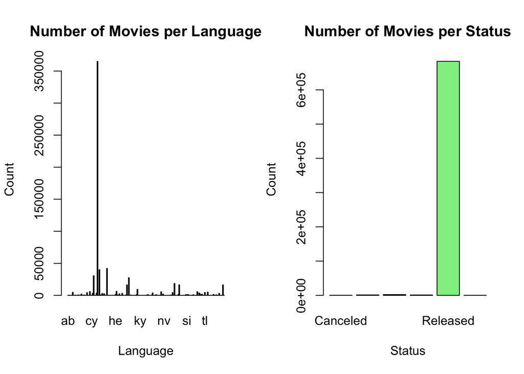

```r
# Bar plot for original_language
barplot(table(movie_final$original_language), main="Number of Movies per Language", col="lightcoral", xlab="Language", ylab="Count")

# Bar plot for status
barplot(table(movie_final$status), main="Number of Movies per Status", col="lightgreen", xlab="Status", ylab="Count")
```

```r
# Correlation matrix for numerical variables
cor_matrix <- cor(movie_final[, c("budget", "revenue", "popularity", "runtime", "vote_average", "vote_count")])
print("Correlation Matrix:")
```

```
## [1] "Correlation Matrix:"
```

```r
print(cor_matrix)
```

```
##                     budget       revenue    popularity       runtime
## budget        1.000000e+00  4.959405e-01  1.456636e-01 -5.015435e-05
## revenue       4.959405e-01  1.000000e+00  1.846044e-01 -4.769673e-05
## popularity    1.456636e-01  1.846044e-01  1.000000e+00 -7.362385e-05
## runtime      -5.015435e-05 -4.769673e-05 -7.362385e-05  1.000000e+00
## vote_average  5.532754e-02  6.587508e-02  6.202515e-02 -1.178986e-03
## vote_count    4.352714e-01  7.683793e-01  1.526400e-01 -7.634812e-05
##              vote_average    vote_count
## budget        0.055327541  4.352714e-01
## revenue       0.065875080  7.683793e-01
## popularity    0.062025152  1.526400e-01
## runtime      -0.001178986 -7.634812e-05
## vote_average  1.000000000  1.003992e-01
## vote_count    0.100399150  1.000000e+00
```

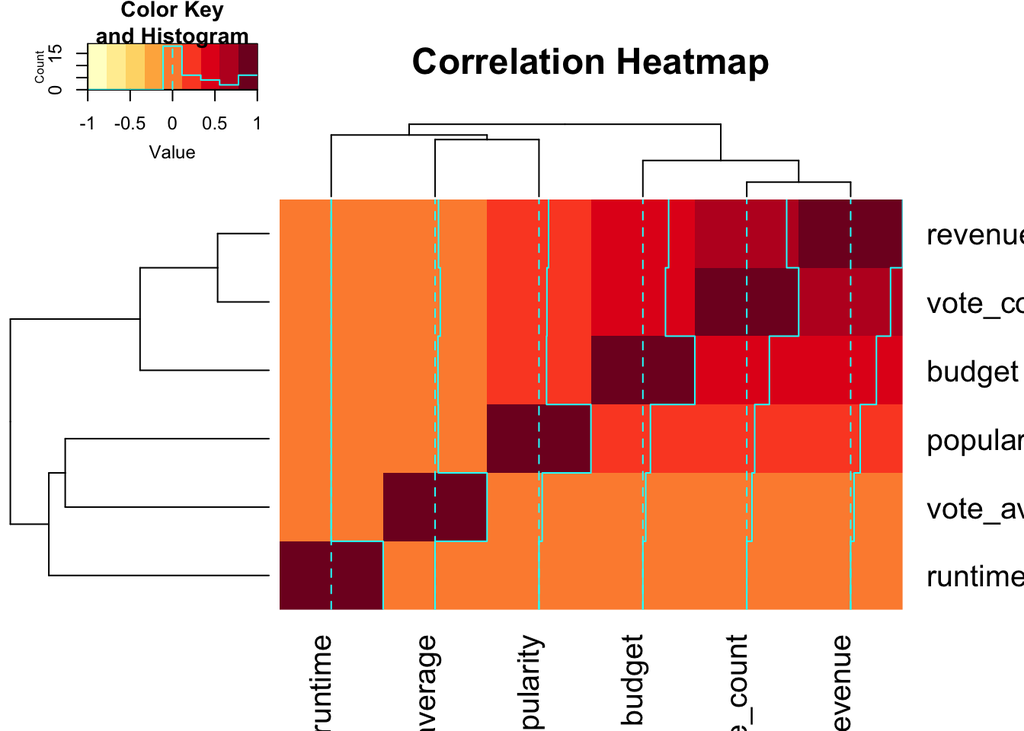

```r
# Heatmap for the correlation matrix
library(gplots)
library(RColorBrewer)
heatmap.2(cor_matrix, main="Correlation Heatmap", col=brewer.pal(9, "YlOrRd"))
```

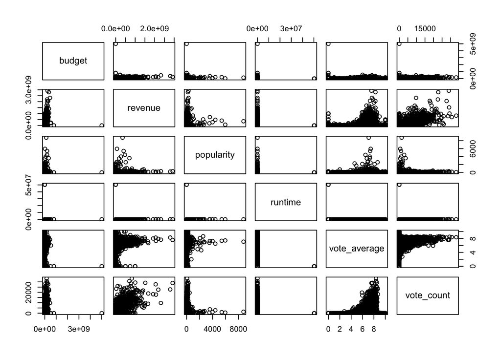

```r
# Scatter plot matrix for selected numerical variables
pairs(movie_final[, c("budget", "revenue", "popularity", "runtime", "vote_average", "vote_count")])
```

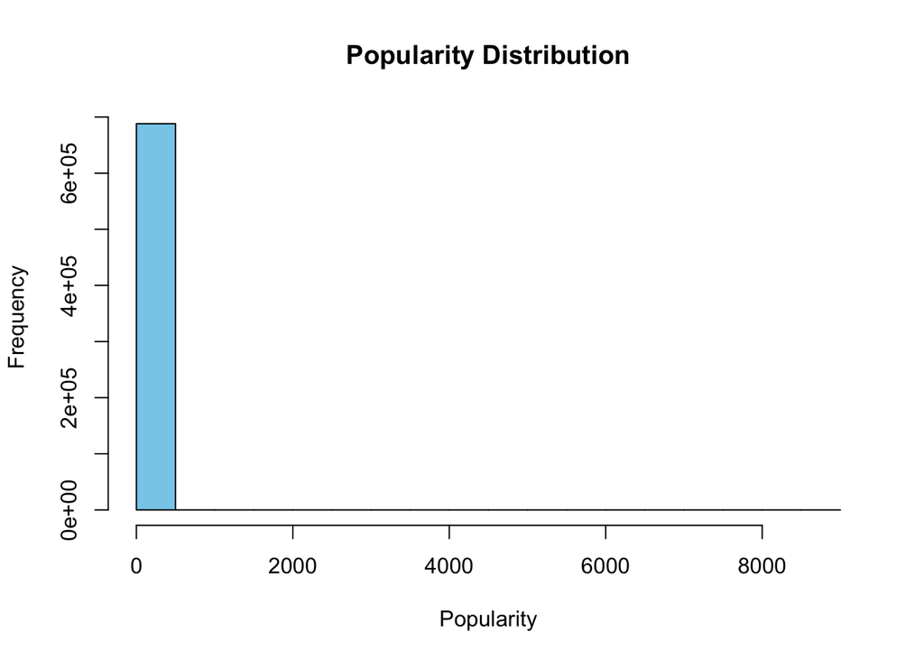

```r
# Histogram for popularity
hist(movie_final$popularity, main="Popularity Distribution", col="skyblue", xlab="Popularity")
```

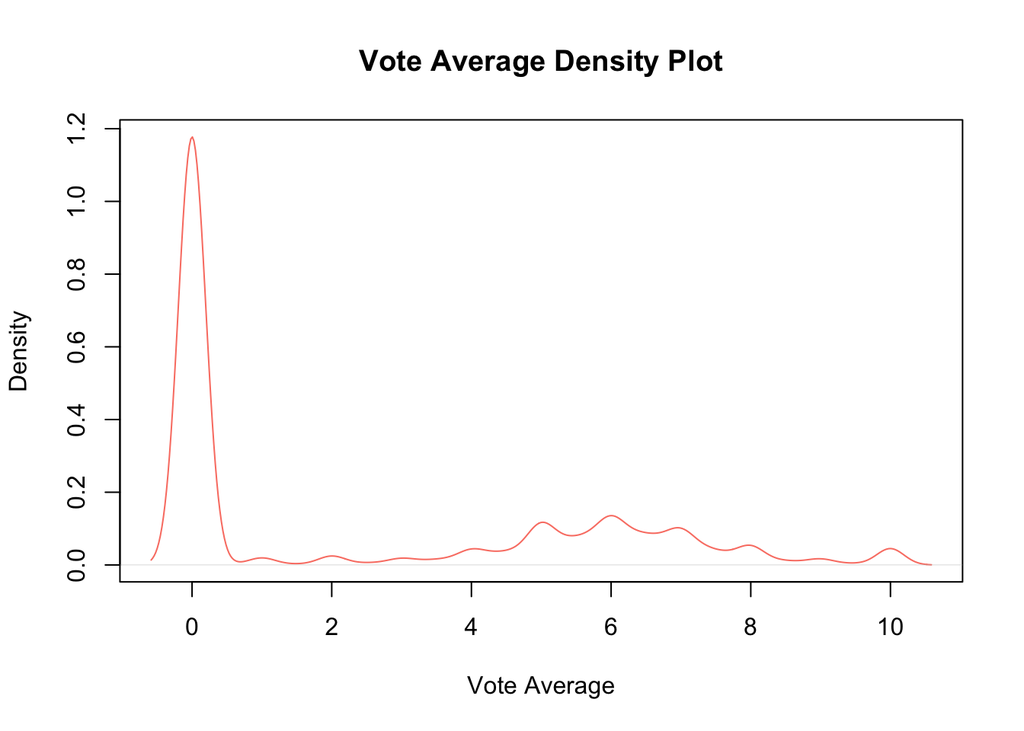

```r
# Density plot for vote_average
plot(density(movie_final$vote_average), main="Vote Average Density Plot", col="salmon", xlab="Vote Average")
```

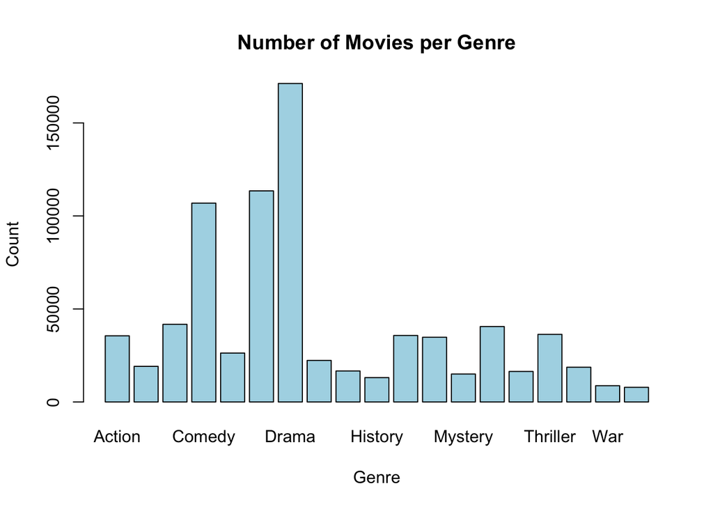

```r
# Bar plot for genres (assuming genres are separated by '-')
genres <- unlist(strsplit(as.character(movie_final$genres), "-"))
barplot(table(genres), main="Number of Movies per Genre", col="lightblue", xlab="Genre", ylab="Count")
```

```r
# Summary statistics for runtime
summary(movie_final$runtime)
```

```
##     Min.  1st Qu.   Median     Mean  3rd Qu.     Max.
##        0        5       50      199       90 50505050
```

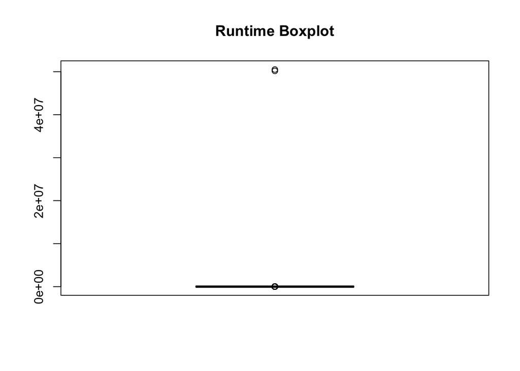

```r
# Boxplot for runtime
boxplot(movie_final$runtime, main="Runtime Boxplot", col="lightcoral")
```

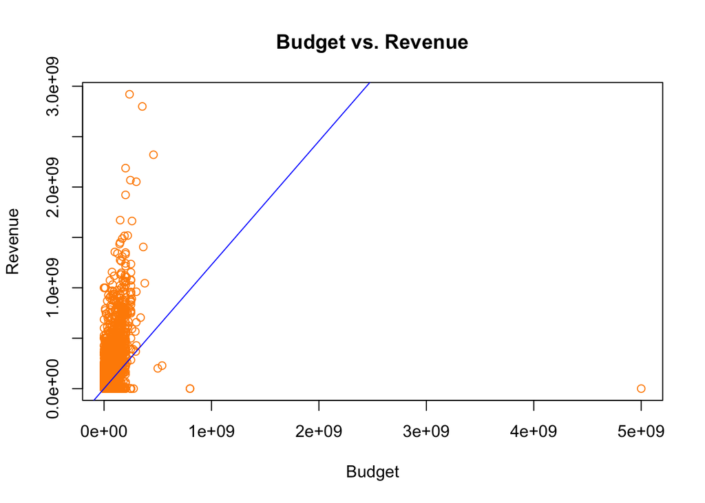

```r
# Scatter plot between budget and revenue
plot(movie_final$budget, movie_final$revenue, main="Budget vs. Revenue", col="darkorange", xlab="Budget", ylab="Revenue")

# Regression line between budget and revenue
abline(lm(revenue ~ budget, data=movie_final), col="blue")
```

```r
# Pairwise correlation for selected numerical variables
cor(movie_final[, c("budget", "revenue", "popularity", "runtime", "vote_average", "vote_count")])
```

```
##                     budget       revenue    popularity       runtime
## budget        1.000000e+00  4.959405e-01  1.456636e-01 -5.015435e-05
## revenue       4.959405e-01  1.000000e+00  1.846044e-01 -4.769673e-05
## popularity    1.456636e-01  1.846044e-01  1.000000e+00 -7.362385e-05
## runtime      -5.015435e-05 -4.769673e-05 -7.362385e-05  1.000000e+00
## vote_average  5.532754e-02  6.587508e-02  6.202515e-02 -1.178986e-03
## vote_count    4.352714e-01  7.683793e-01  1.526400e-01 -7.634812e-05
##              vote_average    vote_count
## budget        0.055327541  4.352714e-01
## revenue       0.065875080  7.683793e-01
## popularity    0.062025152  1.526400e-01
## runtime      -0.001178986 -7.634812e-05
## vote_average  1.000000000  1.003992e-01
## vote_count    0.100399150  1.000000e+00
```